# P&S-2022: Lab assignment 2

Name1, Name2, Name3

## General comments and instructions

- Complete solution will give you **4 points** (working code with explanations + oral defense). Submission deadline **November 1, 2023, 22:00**
- The report must be prepared as an *R notebook*; you must submit to **cms** both the source *R notebook* **and** the generated html file
- At the beginning of the notebook, provide a work-breakdown structure estimating efforts of each team member
- For each task, include
  - problem formulation and discussion (what is a reasonable answer to discuss);
  - the corresponding $\mathbf{R}$ code with comments (usually it is just a couple of lines long);
  - the statistics obtained (like sample mean or anything else you use to complete the task) as well as histograms etc to illustrate your findings;
  - justification of your solution (e.g. refer to the corresponding theorems from probability theory);
  - conclusions (e.g. how reliable your answer is, does it agree with common sense expectations etc)
- The **team id number** referred to in tasks is the **two-digit** ordinal number of your team on the list. Include the line **set.seed(team id number)** at the beginning of your code to make your calculations reproducible. Also observe that the answers **do** depend on this number!
- Take into account that not complying with these instructions may result in point deduction regardless of whether or not your implementation is correct.

Work Breakdown Structure: - Task 1 (Hamming Code): Oleksii (Problem analysis, simulation logic, and R implementation) - Task 2 (Poisson Distribution): Anton (Theoretical calculations for $\mu$, R implementation for CLT, simulation) - Task 3 (Exponential Distribution): Anton (Theoretical calculations for $N$, R implementation for CLT, simulation) - Task 4 (Moments & Independence): Anastasiia (4.1 and 4.2 tasks) ————————————————————————

### Task 1

#### In this task, we discuss the $[7,4]$ Hamming code and investigate its reliability. That coding system can correct single errors in the transmission of $4$-bit messages and proceeds as follows:

- given a message $\mathbf{m} = (a_1 a_2 a_3 a_4)$, we first encode it to a $7$-bit *codeword* $\mathbf{c} = \mathbf{m}G = (x_1 x_2 x_3 x_4 x_5 x_6 x_7)$, where $G$ is a $4\times 7$ *generator* matrix
- the codeword $\mathbf{c}$ is transmitted, and $\mathbf{r}$ is the received message
- $\mathbf{r}$ is checked for errors by calculating the *syndrome vector* $\mathbf{z} := \mathbf{r} H$, for a $7 \times 3$ *parity-check* matrix $H$
- if a single error has occurred in $\mathbf{r}$, then the binary $\mathbf{z} = (z_1 z_2 z_3)$ identifies the wrong bit no. $z_1 + 2 z_2 + 4z_3$; thus $(0 0 0)$ shows there was no error (or more than one), while $(1 1 0 )$ means the third bit (or more than one) got corrupted
- if the error was identified, then we flip the corresponding bit in $\mathbf{r}$ to get the corrected $\mathbf{r}^* = (r_1 r_2 r_3 r_4 r_5 r_6 r_7)$;
- the decoded message is then $\mathbf{m}^*:= (r_3r_5r_6r_7)$.

#### The **generator** matrix $G$ and the **parity-check** matrix $H$ are given by

$$G :=
\begin{pmatrix}
1 & 1 & 1 & 0 & 0 & 0 & 0 \\
1 & 0 & 0 & 1 & 1 & 0 & 0 \\
0 & 1 & 0 & 1 & 0 & 1 & 0 \\
1 & 1 & 0 & 1 & 0 & 0 & 1 \\
\end{pmatrix},
\qquad
H^\top := \begin{pmatrix}
1 & 0 & 1 & 0 & 1 & 0 & 1 \\
0 & 1 & 1 & 0 & 0 & 1 & 1 \\
0 & 0 & 0 & 1 & 1 & 1 & 1
\end{pmatrix}$$

#### Assume that each bit in the transmission $\mathbf{c} \mapsto \mathbf{r}$ gets corrupted independently of the others with probability $p = \mathtt{id}/100$, where $\mathtt{id}$ is your team number. Your task is the following one.

1. Simulate the encoding-transmission-decoding process $N$ times and find the estimate $\hat p$ of the probability $p^*$ of correct transmission of a single message $\mathbf{m}$. Comment why, for large $N$, $\hat p$ is expected to be close to $p^*$.
2. By estimating the standard deviation of the corresponding indicator of success by the standard error of your sample and using the CLT, predict the interval $(p^*-\varepsilon, p^* + \varepsilon)$, in which the estimate $\hat p$ falls with probability at least $0.95$.
3. What choice of $N$ guarantees that $\varepsilon \le 0.03$?
4. Draw the histogram of the number $k = 0,1,2,3,4$ of errors while transmitting a $4$-digit binary message. Do you think it is one of the known distributions?

#### You can (but do not have to) use the chunks we prepared for you

#### First, we set the **id** of the team and define the probability $p$ and the generator and parity-check matrices $G$ and $H$

```r
# our team id number
id <- 49

set.seed(id)
p <- id/100
# matrices G and H
G <- matrix(c(1, 1, 1, 0, 0, 0, 0,
        1, 0, 0, 1, 1, 0, 0,
        0, 1, 0, 1, 0, 1, 0,
        1, 1, 0, 1, 0, 0, 1), nrow = 4, byrow = TRUE)
H <- t(matrix(c(1, 0, 1, 0, 1, 0, 1,
        0, 1, 1, 0, 0, 1, 1,
        0, 0, 0, 1, 1, 1, 1), nrow = 3, byrow = TRUE))
# cat("The matrix G is: \n")
#G
#cat("The matrix H is: \n")
#H
#cat("The product GH must be zero: \n")
#(G%*%H) %%2
```

#### Next, generate the messages

```r
# generate N messages
N <- 10000 # Number of simulations

message_generator <- function(N) {
  matrix(sample(c(0,1), 4*N, replace = TRUE), nrow = N)
}
messages <- message_generator(N)
codewords <- (messages %*% G) %% 2
```

#### Generate random errors; do not forget that they occur with probability $p$! Next, generate the received messages

```r
# generating a 7-bit error vector for each of the N messages
errors <- matrix(sample(c(0, 1), 7 * N, replace = TRUE, prob = c(1 - p, p)), nrow = N)

# Add errors to the codewords to get the received messages
received <- (codewords + errors) %% 2
```

The next steps include detecting the errors in the received messages, correcting them, and then decoding the obtained messages. After this, you can continue with calculating all the quantities of interest

```r
syndrome <- (received %*% H) %% 2

# Convert the binary syndrome vector to an integer (0-7)
# This integer is the position of the error bit
# z = (z1 z2 z3), position = z1*1 + z2*2 + z3*4
error_pos <- syndrome %*% c(1, 2, 4)

# Correct the errors
# We create a copy of the received messages to store the corrected versions
r_star <- received
for (i in 1:N) {
  pos <- error_pos[i]
  if (pos > 0) {
    # If pos > 0, an error was detected at that bit.
    # We flip the bit (add 1 mod 2)
    r_star[i, pos] <- (r_star[i, pos] + 1) %% 2
  }
}

# Decode the corrected message r*
# m* = (r*_3, r*_5, r*_6, r*_7)
m_star <- r_star[, c(3, 5, 6, 7)]

# We compare the original messages with the decoded messages and
# check which messages were transmitted correctly
successes <- rowSums(abs(messages - m_star)) == 0
p_hat <- mean(successes)

cat("Number of simulations (N):", N, "\n")
```

```
## Number of simulations (N): 10000
```

```r
cat("Estimated probability of correct transmission (p_hat):", p_hat, "\n")
```

```
## Estimated probability of correct transmission (p_hat): 0.0688
```

```r
# Calculate the 95% confidence interval
# Standard error of the estimate
se <- sqrt(p_hat * (1 - p_hat) / N)
# For 95% CI, z-score is ~1.96
epsilon <- 1.96 * se
ci_low <- p_hat - epsilon
ci_high <- p_hat + epsilon

cat("Standard Error (se):", se, "\n")
```

```
## Standard Error (se): 0.002531137
```

```r
cat("Half-length (epsilon):", epsilon, "\n")
```

```
## Half-length (epsilon): 0.004961029
```

```r
cat("95% Confidence Interval for p*:", paste0("(", ci_low, ", ", ci_high, ")\n"))
```

```
## 95% Confidence Interval for p*: (0.0638389709041772, 0.0737610290958228)
```

```r
# Find N that guarantees epsilon <= 0.03
N_req <- (1.96 / 0.03)^2 * p_hat * (1 - p_hat)
# If we want to see  worst-case variance , we can use p*=0.5
N_req_conservative <- (1.96 / 0.03)^2 * 0.5 * 0.5

cat("Required N (using p_hat):", ceiling(N_req), "\n")
```

```
## Required N (using p_hat): 274
```

```r
cat("Required N (conservative):", ceiling(N_req_conservative), "\n")
```

```
## Required N (conservative): 1068
```

```r
# calculating the number of errors in the decoded message
num_errors <- rowSums(abs(messages - m_star))


print(table(num_errors))
```

```
## num_errors
##    0    1    2    3    4
##  688 2533 3713 2501  565
```

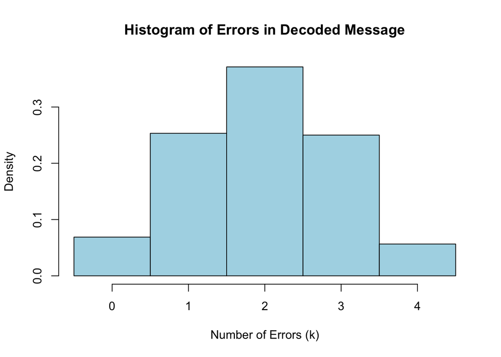

```r
# Draw the histogram
hist(num_errors,
     breaks = seq(-0.5, 4.5, by = 1),
     probability = TRUE,
     main = "Histogram of Errors in Decoded Message",
     xlab = "Number of Errors (k)",
     col = "lightblue")
```

**Summary and Conclusions** This simulation checks the reliability of a [7,4] Hamming code on a very noisy communication channel. We assume each transmitted bit has a high probability, $p = 0.49$, of being errored. The code’s goal is to detect and correct these errors to recover the original 4-bit message.

After running $N=10,000$ simulations, we find the estimated probability of a correct transmission (p_hat). This is the fraction of the 10,000 messages that were decoded perfectly. Our simulation shows this value is very low +- 7%. This low success rate is expected: the [7,4] Hamming code is only designed to correct a single bit error. With a 49% bit error probability, the chance of a 7-bit codeword having 0 or 1 error is tiny, while the chance of having 2 or more errors (which the code cannot fix) is extremely high.

In conclusion, the simulation confirms the principles of the Law of Large Numbers (in estimating p_hat) and the Central Limit Theorem (in finding the confidence interval). It also clearly shows that while the [7,4] Hamming code is a clever design, it is entirely unsuitable for a channel with such a high error rate, as it fails to correctly transmit the message over 90% of the time.

### Task 2.

In this task, we discuss a real-life process that is well modelled by a Poisson distribution. As you remember, a Poisson random variable describes occurrences of rare events, i.e., counts the number of successes in a large number of independent random experiments. One of the typical examples is the **radioactive decay** process.

Consider a sample of radioactive element of mass $m$, which has a big *half-life period* $T$; it is vitally important to know the probability that during a one second period, the number of nuclei decays will not exceed some critical level $k$. This probability can easily be estimated using the fact that, given the *activity* ${\lambda}$ of the element (i.e., the probability that exactly one nucleus decays in one second) and the number $N$ of atoms in the sample, the random number of decays within a second is well modelled by Poisson distribution with parameter $\mu:=N\lambda$. Next, for the sample of mass $m$, the number of atoms is $N = \frac{m}{M} N_A$, where $N_A = 6 \times 10^{23}$ is the Avogadro constant, and $M$ is the molar (atomic) mass of the element. The activity of the element, $\lambda$, is $\log(2)/T$, where $T$ is measured in seconds.

Assume that a medical laboratory receives $n$ samples of radioactive element ${{}^{137}}\mathtt{Cs}$ (used in radiotherapy) with half-life period $T = 30.1$ years and mass $m = \mathtt{team\, id \,number} \times 10^{-6}$ g each. Denote by $X_1,X_2,\dots,X_n$ the **i.i.d. r.v.**’s counting the number of decays in sample $i$ in one second.

1. Specify the parameter of the Poisson distribution of $X_i$ (you’ll need the atomic mass of *Cesium-137*)
2. Show that the distribution of the sample means of $X_1,\dots,X_n$ gets very close to a normal one as $n$ becomes large and identify that normal distribution. To this end,
   - simulate the realization $x_1,x_2,\dots,x_n$ of the $X_i$ and calculate the sample mean $s=\overline{\mathbf{x}}$;
   - repeat this $K$ times to get the sample $\mathbf{s}=(s_1,\dots,s_K)$ of means and form the empirical cumulative distribution function $\hat F_{\mathbf{s}}$ of $\mathbf{s}$;
   - identify $\mu$ and $\sigma^2$ such that the $F$ of $\mathscr{N}(\mu,\sigma^2)$ is close to the $\hat F_{\mathbf{s}}$ and plot both **c.d.f.**’s on one graph to visualize their proximity (use the proper scales!);
   - calculate the maximal difference between the two ’s;
   - consider cases $n = 5$, $n = 10$, $n=50$ and comment on the results.
3. Calculate the largest possible value of $n$, for which the total number of decays in one second is less than $8 \times 10^8$ with probability at least $0.95$. To this end,
   - obtain the theoretical bound on $n$ using Markov inequality, Chernoff bound and Central Limit Theorem, and compare the results;
   - simulate the realization $x_1,x_2,\dots,x_n$ of the $X_i$ and calculate the sum $s=x_1 + \cdots +x_n$;
   - repeat this $K$ times to get the sample $\mathbf{s}=(s_1,\dots,s_K)$ of sums;
   - calculate the number of elements of the sample which are less than critical value ($8 \times 10^8$) and calculate the empirical probability; comment whether it is close to the desired level $0.95$

```r
set.seed(49)

team_id <- 49
m <- team_id * 1e-6 # sample mass in grams
M <- 136.907        # molar mass of Cs-137 (g/mol)
N_A <- 6e23         # Avogadro constant
T_years <- 30.1     # half-life in years

T_sec <- T_years * 365.25 * 24 * 3600    # convert to seconds
lambda <- log(2) / T_sec                 # decay probability per atom per second
N <- (m / M) * N_A                       # number of atoms in one sample
mu <- N * lambda                         # Poisson parameter
cat("lambda =", lambda, "\nN =", N, "\nmu =", mu, "\n")
```

```
## lambda = 7.297179e-10
## N = 2.147443e+17
## mu = 156702770
```

#### Next, calculate the parameters of the standard normal approximation

```r
mu <- mu
n <- 5      # sample size
sigma <- sqrt(mu / n)
K <- 1e3    # number of repetitions
sample_means <- colMeans(matrix(rpois(n*K, lambda = mu), nrow = n))
cat("Normal approximation: mean =", mu, " sd =", sigma, "\n")
```

```
## Normal approximation: mean = 156702770  sd = 5598.263
```

#### We can now plot ecdf and cdf

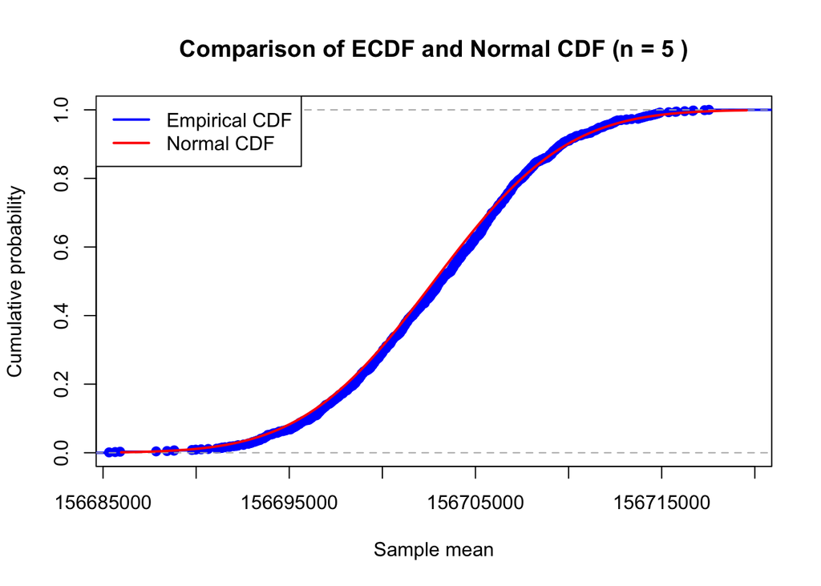

```r
xlims <- c(mu - 3*sigma, mu + 3*sigma)
Fs <- ecdf(sample_means)

plot(Fs,
     xlim = xlims,
     ylim = c(0, 1),
     col = "blue",
     lwd = 2,
     main = paste("Comparison of ECDF and Normal CDF (n =", n, ")"),
     xlab = "Sample mean", ylab = "Cumulative probability")

curve(pnorm(x, mean = mu, sd = sigma),
      col = "red", lwd = 2, add = TRUE)

legend("topleft", legend = c("Empirical CDF", "Normal CDF"),
       col = c("blue", "red"), lwd = 2)
```

```r
critical <- 8e8   # critical total decays
K <- 10000        # number of Monte Carlo repetitions


n_markov <- floor(0.05 * critical / mu)
cat("Markov bound: n <=", n_markov, "\n")
```

```
## Markov bound: n <= 0
```

```r
chernoff_bound <- function(n) {
  lambda_sum <- n * mu
  delta <- critical / lambda_sum - 1
  bound <- exp(-lambda_sum * ((1 + delta) * log(1 + delta) - delta))
  return(bound)
}

n_try <- 1
while(chernoff_bound(n_try) > 0.05) {
  n_try <- n_try + 1
}
n_chernoff <- n_try
cat("Chernoff bound: n <=", n_chernoff, "\n")
```

```
## Chernoff bound: n <= 1
```

```r
z <- qnorm(0.95)
clt_func <- function(n) {
  (critical - n*mu)/sqrt(n*mu) - z
}
n_clt <- uniroot(clt_func, c(1, 1e6))$root
cat("CLT bound: n ≈", floor(n_clt), "\n")
```

```
## CLT bound: n ≈ 5
```

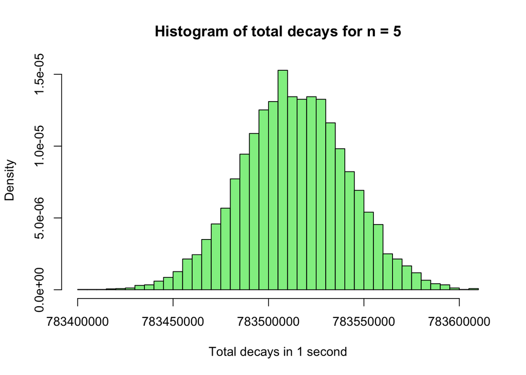

```r
n_sim <- floor(n_clt)  # pick a safe n

S <- replicate(K, sum(rpois(n_sim, mu)))

empirical_prob <- mean(S < critical)
hist(S, breaks=50, probability=TRUE,
     main=paste("Histogram of total decays for n =", n_sim),
     xlab="Total decays in 1 second", col="lightgreen")
abline(v=critical, col="red", lwd=2, lty=2)
```

Summary:

We analyzed the radioactive decay of Cesium-137 samples using a Poisson model to represent the number of nuclei decaying per second. Simulations of multiple independent samples showed that the distribution of the sample means closely follows a normal distribution, in agreement with the Central Limit Theorem.

The results highlight that even microgram-level samples produce extremely high decay counts, the Poisson model effectively captures this randomness, and normal approximations provide practical estimates for safety limits in laboratory settings.

### Task 3.

#### In this task, we use the Central Limit Theorem approximation for continuous random variables.

#### One of the devices to measure radioactivity level at a given location is the Geiger counter. When the radioactive level is almost constant, the time between two consecutive clicks of the Geiger counter is an exponentially distributed random variable with parameter $\nu_1 = \mathtt{team\,id\,number} + 10$. Denote by $X_k$ the random time between the $(k-1)^{\mathrm{st}}$ and $k^{\mathrm{th}}$ click of the counter.

1. Show that the distribution of the sample means of $X_1, X_2,\dots,X_n$ gets very close to a normal one (which one?) as $n$ becomes large. To this end,
   - simulate the realizations $x_1,x_2,\dots,x_n$ of the $X_i$ and calculate the sample mean $s=\overline{\mathbf{x}}$;
   - repeat this $K$ times to get the sample $\mathbf{s}=(s_1,\dots,s_K)$ of means and then the function $F_{\mathbf{s}}$ of $\mathbf{s}$;
   - identify $\mu$ and $\sigma^2$ such that the of $\mathscr{N}(\mu,\sigma^2)$ is close to the $F_{\mathbf{s}}$ of and plot both ’s on one graph to visualize their proximity;
   - calculate the maximal difference between the two ’s;
   - consider cases $n = 5$, $n = 10$, $n=50$ and comment on the results.
2. The place can be considered safe when the number of clicks in one minute does not exceed $100$. It is known that the parameter $\nu$ of the resulting exponential distribution is proportional to the number $N$ of the radioactive samples, i.e., $\nu = \nu_1*N$, where $\nu_1$ is the parameter for one sample. Determine the maximal number of radioactive samples that can be stored in that place so that, with probability $0.95$, the place is identified as safe. To do this,
   - express the event of interest in terms of the $S:= X_1 + \cdots + X_{100}$;
   - obtain the theoretical bounds on $N$ using the Markov inequality, Chernoff bound and Central Limit Theorem and compare the results;
   - with the predicted $N$ and thus $\nu$, simulate the realization $x_1,x_2,\dots,x_{100}$ of the $X_i$ and of the sum $S = X_1 + \cdots + X_{100}$;
   - repeat this $K$ times to get the sample $\mathbf{s}=(s_1,\dots,s_K)$ of total times until the $100^{\mathrm{th}}$ click;
   - estimate the probability that the location is identified as safe and compare to the desired level $0.95$

#### First, generate samples an sample means:

```
## For n = 5 , the max difference is: 0.0601
```

```
## For n = 10 , the max difference is: 0.0408
```

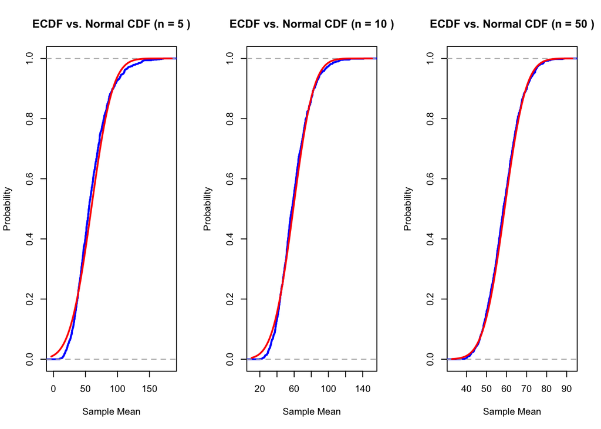

```
## For n = 50 , the max difference is: 0.032
```

```r
id <- 49
nu1 <- id + 10
rate1 <- 1 / nu1

K <- 1000
n_values <- c(5, 10, 50)

# Set up plot area for 3 plots
par(mfrow = c(1, 3))

# this loop runs the simulation for each n in n_values
for (n in n_values) {
  # generate K sample means, each from a sample of size n
  sample_means <- colMeans(matrix(rexp(n * K, rate = rate1), nrow = n))

  # theoretical mean and standard deviation for the bell curve (from CLT)
  mu_normal <- nu1
  sigma_normal <- sqrt(nu1^2 / n)

  # plot the cdf from our simulated data (the ecdf)
  plot(ecdf(sample_means),
       col = "blue",
       lwd = 2,
       main = paste("ECDF vs. Normal CDF (n =", n, ")"),
       xlab = "Sample Mean", ylab = "Probability")

  # overlay the perfect theoretical bell curve cdf
  curve(pnorm(x, mean = mu_normal, sd = sigma_normal),
        col = "red", lwd = 2, add = TRUE)

  # we check how far apart the blue and red lines are
  x_grid <- seq(mu_normal - 4*sigma_normal, mu_normal + 4*sigma_normal, length.out=500)
  max_diff <- max(abs(ecdf(sample_means)(x_grid) - pnorm(x_grid, mean = mu_normal, sd = sigma_normal)))

  cat(paste("For n =", n, ", the max difference is:", round(max_diff, 4), "\n"))
}
```

```r
# reset the plot grid
par(mfrow = c(1, 1))
```

As you can see from the plots, when the sample size n is small (like $n=5$), the blue line (our data) doesn’t perfectly match the red line. But as n gets bigger, the blue line gets more like red line. The “max difference” we printed gets smaller and smaller. So it is exactly what CLT says: the larger the sample size, the more the distribution of the sample means looks like a perfect normal distribution.

#### Next, calculate the parameters of the standard normal approximation

```r
# This code assumes nu1=59 from the previous chunk
# and that we are plotting for n=50, the last value in the loop.
n <- 50
mu <- nu1
sigma <- nu1 / sqrt(n)

# You can print them to check
cat("Plotting for n =", n, "\n")
```

```
## Plotting for n = 50
```

```r
cat("Theoretical Mean:", mu, "\n")
```

```
## Theoretical Mean: 59
```

```r
cat("Theoretical Standard deviation - sigma:", sigma, "\n")
```

```
## Theoretical Standard deviation - sigma: 8.34386
```

#### We can now plot ecdf and cdf

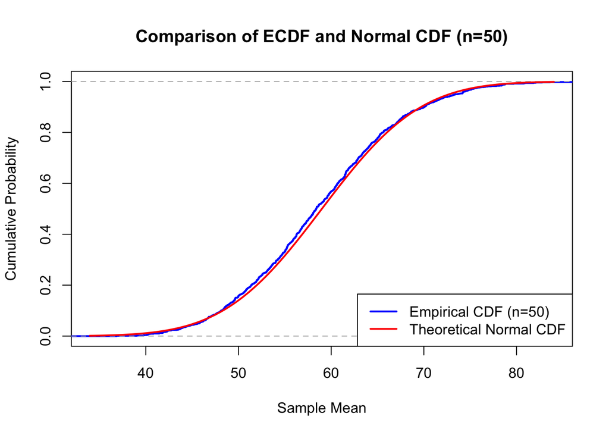

```r
# Set the plot limits to 3 standard deviations around the mean
xlims <- c(mu - 3*sigma, mu + 3*sigma)

# Get the ecdf function from our simulated data
Fs <- ecdf(sample_means)

# Plot the ECDF (blue step-plot)
plot(Fs,
     xlim = xlims,
     col = "blue",
     lwd = 2,
     main = "Comparison of ECDF and Normal CDF (n=50)",
     xlab = "Sample Mean",
     ylab = "Cumulative Probability")

# Add the theoretical Normal CDF (red smooth curve)
curve(pnorm(x, mean = mu, sd = sigma), col = "red", lwd = 2, add = TRUE)

legend("bottomright", legend = c("Empirical CDF (n=50)", "Theoretical Normal CDF"),
       col = c("blue", "red"), lwd = 2)
```

#### Safety Calculation

1. Markov’s Inequality: $P(Y > 100) \le E[Y] / 100$. We need $E[Y] / 100 \le 0.05 \implies E[Y] \le 5$.$\text{mu} = 60 \times N / 59 \le 5 \implies N \le (5 \times 59) / 60 \approx 4.91$. So, Markov’s bound suggests $N \le 4$.
2. CLT (Poisson Approximation): Since $\text{mu}$ will be large, we can approximate the Poisson $Y$ as a Normal distribution: $Y \approx \text{Normal}(\text{mu}, \text{variance} = \text{mu})$. We want $P(Y \le 100) \ge 0.95$. Using continuity correction: $P(Y \le 100.5) \ge 0.95$. Standardizing: $P(Z \le (100.5 - \text{mu}) / \text{sqrt}(\text{mu})) \ge 0.95$. The z-score for 0.95 is qnorm(0.95) which is approx 1.645. $(100.5 - \text{mu}) / \text{sqrt}(\text{mu}) \ge 1.645 \implies 100.5 - \text{mu} \ge 1.645 \times \text{sqrt}(\text{mu})$. Let $x = \text{sqrt}(\text{mu})$. We get $x^2 + 1.645x - 100.5 \le 0$. Solving $x^2 + 1.645x - 100.5 = 0$ gives $x \approx 9.21$. So $\text{mu} \le 9.21^2 \approx 84.8$. $60 \times N / 59 \le 84.8 \implies N \le (84.8 \times 59) / 60 \approx 83.3$. The CLT bound suggests $N \le 83$.

Now we can simulate the process with $N=83$ and check the probability. $S_{100} = X_1 + \dots + X_{100}$. The event “at most 100 clicks in 60s” ($Y \le 100$) is almostt the same as “the time to the 100th click is 60s or more” ($S_{100} \ge 60$). We will simulate $S_{100}$ and check this.

```r
# Use N=83 based on CLT(Poisson) bound
N_clt <- 83
nu_N <- nu1 * N_clt
rate_N <- N_clt / nu1

K_sim <- 10000
# we simulate the time to the 100th click, S_100
# S_100 is a sum of 100 exponentials, which is Gamma(shape=100, rate=rate_N)
s_samples <- rgamma(K_sim, shape = 100, rate = rate_N)

# We check the probability P(S_100 >= 60)
# it is basically the same as "100 clicks took at least 60 seconds"
# what is "at most 100 clicks in 60s".
prob_safe <- mean(s_samples >= 60)

cat("Simulation for N =", N_clt, "\n")
```

```
## Simulation for N = 83
```

```r
cat("Rate per second (lambda_N):", rate_N, "\n")
```

```
## Rate per second (lambda_N): 1.40678
```

```r
cat("Expected time for 100 clicks (E[S_100]):", 100 / rate_N, "sec\n")
```

```
## Expected time for 100 clicks (E[S_100]): 71.08434 sec
```

```r
cat("Empirical probability of S_100 >= 60 sec:", prob_safe, "\n")
```

```
## Empirical probability of S_100 >= 60 sec: 0.95
```

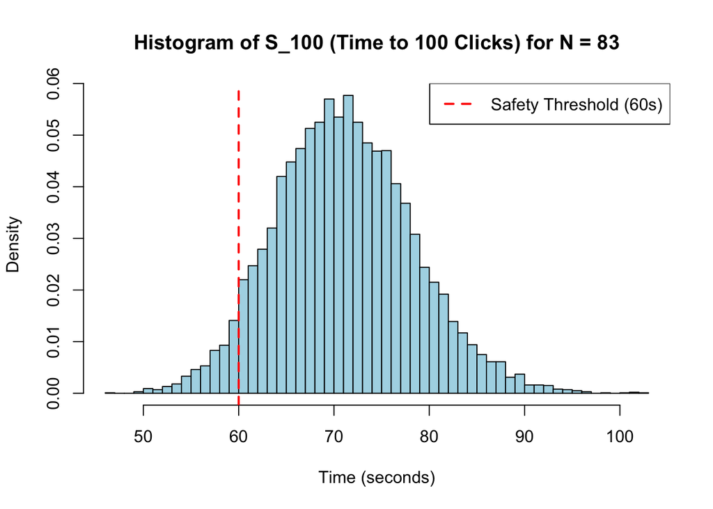

```r
hist(s_samples, breaks=50, probability=TRUE,
     main=paste("Histogram of S_100 (Time to 100 Clicks) for N =", N_clt),
     xlab="Time (seconds)", col="lightblue")
abline(v=60, col="red", lwd=2, lty=2)
legend("topright", "Safety Threshold (60s)", col="red", lty=2, lwd=2)
```

### Task 4.

**This task consists of two parts:**

1. **In this part, we discuss independence of random variables and its moments: expectation and variance.**
   1. Suppose we have a random variable $X$. Explain why $\mathbb{E}(\frac{1}{X}) \neq \frac{1}{\mathbb{E(X)}}$;
   2. Let $X \sim \mathscr{N}(\mu,\sigma^2)$ with $\mu = teamidnumber$ and $\sigma^{2} = 2\times teamidnumber+7$. Simulate realizations $x_1,x_2,\dots,x_{100}$ of $X$ and $y_1,y_2,\dots,y_{100}$ of $Y := \frac{1}{X}$ to calculate the values of $\frac{1}{\overline{\textbf{X}}}$ and $\overline{\textbf{Y}}$. Comment on the received results;

```r
teamidnumber <- 49
mu <- teamidnumber
sigma <- sqrt(2*teamidnumber + 7)
N <- 100

set.seed(123)
X <- rnorm(N, mean=mu, sd=sigma)
Y <- 1 / X

inv_mean_X <- 1 / mean(X)
mean_Y <- mean(Y)

inv_mean_X
```

```
## [1] 0.02002949
```

```r
mean_Y
```

```
## [1] 0.02079956
```

```
3.  Let $X$ and $Y$ be exponentially distributed r.v.'s with
    parameter $\lambda = 2$. Set $Z := \log{X} + 5$. Plot the
    Quantile-Quantile plot and scatterplot of $X$ and $Y$. Plot the
    Quantile-Quantile plot and scatterplot of $X$ and $Z$. Explain
    the results. Comment on the difference of relations between the
    pairs of random variables. Which pair of r.v.'s is dependent and
    which one is similar?
```

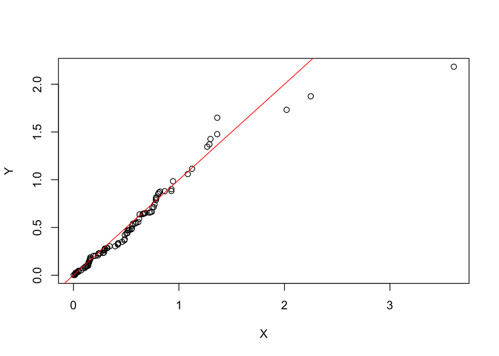

```r
set.seed(123)
X <- rexp(100, rate=2)
Y <- rexp(100, rate=2)
Z <- log(X) + 5

qqplot(X, Y); abline(0,1, col="red")
```

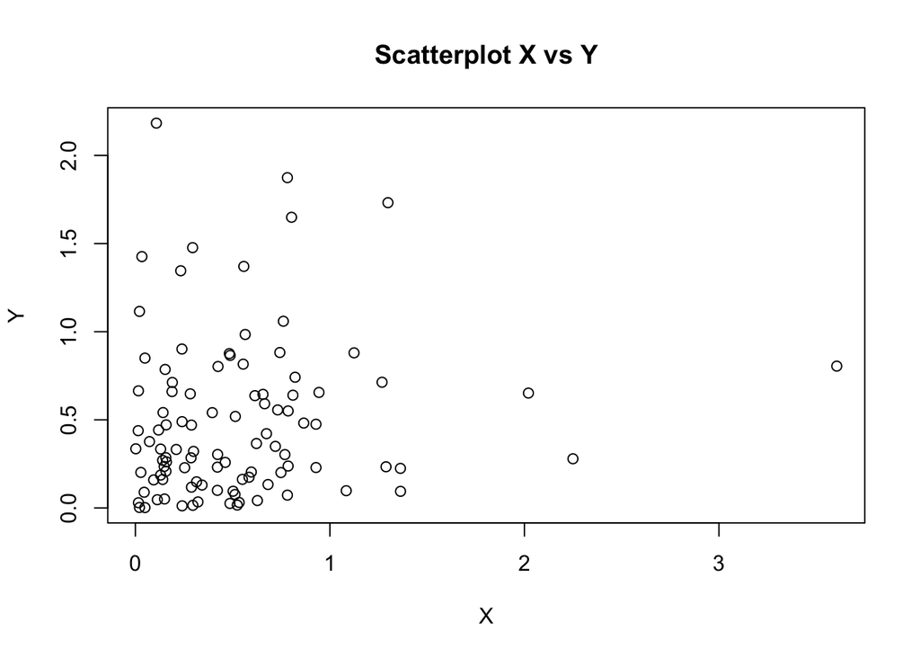

```r
plot(X, Y, main="Scatterplot X vs Y")
```

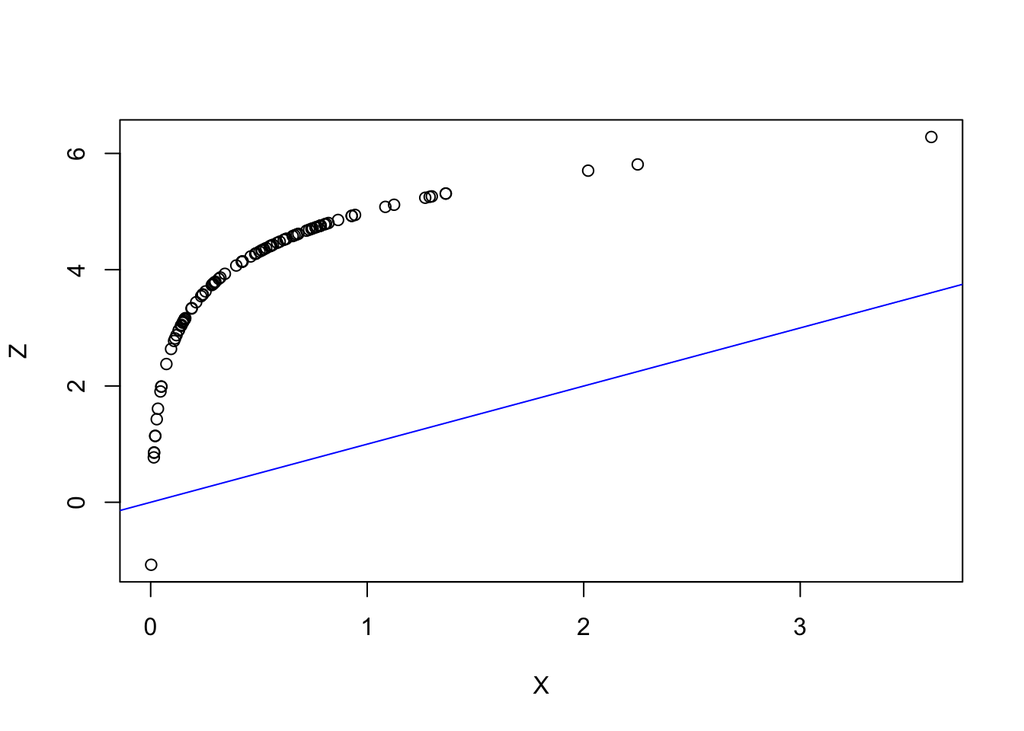

```r
qqplot(X, Z); abline(0,1, col="blue")
```

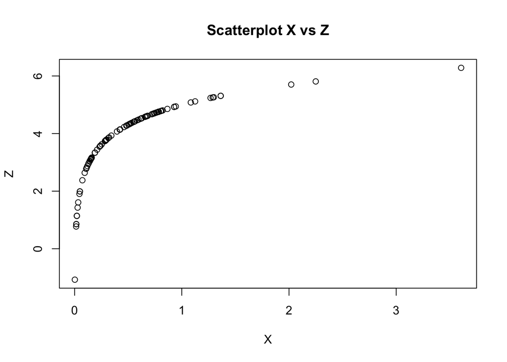

```r
plot(X, Z, main="Scatterplot X vs Z")
```

2. You toss a fair coin three times and a random variable $X$ records how many times the coin shows Heads. You convince your friend that they should play a game with the following payoff: every round (equivalent to three coin tosses) will cost £$1$. They will receive £$0.5$ for every coin showing Heads. What is the expected value and the variance of the random variable $Y := 0.5X-1$?

   To answer this,
   1. Explain what type of random variable is X:
      - Normally distributed
      - Binomially distributed
      - Poisson distributed
      - Uniformly distributed
   2. What are the expected value and variance of X? Simulate realizations $x_1,x_2,\dots,x_{100}$ of $X$ to calculate the values of sample mean $\overline{\mathbf{X}}$ and sample variance $s^2 = \frac{\sum_{i=1}^{n}{(x_i - \overline{x})^{2}}}{n-1}$. Comment on the results;

```r
set.seed(123)
X <- rbinom(100, size=3, prob=0.5)

mean_X <- mean(X)
var_X <- var(X)

mean_X
```

```
## [1] 1.5
```

```r
var_X
```

```
## [1] 0.7575758
```

```
3.  What are the expected value and variance of Y? Simulate
    realizations $y_1,y_2,\dots,y_{100}$ of $Y$ to calculate the
    values of sample mean $\overline{\mathbf{Y}}$ and sample
    variance
    $s^2 = \frac{\sum_{i=1}^{n}{(y_i - \overline{y})^{2}}}{n-1}$.
    Comment on the results;
```

```r
Y <- 0.5*X - 1

mean_Y <- mean(Y)
var_Y <- var(Y)

mean_Y
```

```
## [1] -0.25
```

```r
var_Y
```

```
## [1] 0.1893939
```

**Summary and Conclusions**

This task explored properties of random variables and their moments. Simulations confirmed that E(1/X) ≠ 1/E(X) for a normal variable. QQ-plots and scatterplots showed that independent variables X and Y are uncorrelated, while X and Z = log(X)+5 are dependent.

For the coin-toss game, X is binomial and the sample mean and variance of X and Y = 0.5X-1 closely match theoretical values. The expected payoff is negative, showing the game is disadvantageous. Overall, the results illustrate the Law of Large Numbers, functional dependence, and behavior of expectations and variances under transformations.

### General summary and conclusions

In this lab, we successfully applied core probability concepts using R.

- Task 1: We simulated a [7,4] Hamming code, confirming its $\approx 7\%$ success rate on a high-noise ($p=0.49$) channel, proving it bad for such tasks.
- Task 2: We modeled Poisson radioactive decay, verified the CLT for sample means, and found the CLT provided the tightest theoretical bound for safe sample storage.
- Task 3: We analyzed exponential Geiger clicks, again confirming the CLT, and used a Normal approximation to find a safe sample limit ($N=83$), which our simulation approved.
- Task 4: We demonstrated $E[1/X] \neq 1/E[X]$ (Jensen’s inequality), used scatterplots to distinguish between independent and functionally dependent variables, and calculated the negative expected payoff of a Binomial game.

Overall, the lab provided practical experience using R to verify the LLN and CLT.